# Assessment 1.1

### Part 3

**18. Identify variable(s) which should be factors and transform their type into a factor variable.**

```r
library(forcats)

#is.factor(fastfood$restaurant, item and salad)

# The is.factor tells us if the column has the categorical data or not.

as.factor(fastfood$restaurant)
```

```
##   [1] Mcdonalds   Mcdonalds   Mcdonalds   Mcdonalds   Mcdonalds   Mcdonalds
##   [7] Mcdonalds   Mcdonalds   Mcdonalds   Mcdonalds   Mcdonalds   Mcdonalds
##  [13] Mcdonalds   Mcdonalds   Mcdonalds   Mcdonalds   Mcdonalds   Mcdonalds
##  [19] Mcdonalds   Mcdonalds   Mcdonalds   Mcdonalds   Mcdonalds   Mcdonalds
##  [25] Mcdonalds   Mcdonalds   Mcdonalds   Mcdonalds   Mcdonalds   Mcdonalds
##  [31] Mcdonalds   Mcdonalds   Mcdonalds   Mcdonalds   Mcdonalds   Mcdonalds
##  [37] Mcdonalds   Mcdonalds   Mcdonalds   Mcdonalds   Mcdonalds   Mcdonalds
##  [43] Mcdonalds   Mcdonalds   Mcdonalds   Mcdonalds   Mcdonalds   Mcdonalds
##  [49] Mcdonalds   Mcdonalds   Mcdonalds   Mcdonalds   Mcdonalds   Mcdonalds
##  [55] Mcdonalds   Mcdonalds   Mcdonalds   Chick Fil-A Chick Fil-A Chick Fil-A
##  [61] Chick Fil-A Chick Fil-A Chick Fil-A Chick Fil-A Chick Fil-A Chick Fil-A
##  [67] Chick Fil-A Chick Fil-A Chick Fil-A Chick Fil-A Chick Fil-A Chick Fil-A
##  [73] Chick Fil-A Chick Fil-A Chick Fil-A Chick Fil-A Chick Fil-A Chick Fil-A
##  [79] Chick Fil-A Chick Fil-A Chick Fil-A Chick Fil-A Chick Fil-A Chick Fil-A
##  [85] Sonic       Sonic       Sonic       Sonic       Sonic       Sonic
```

[output cut: 72 more lines]

```r
as.factor(fastfood$item)
```

```
##   [1] Artisan Grilled Chicken Sandwich
##   [2] Single Bacon Smokehouse Burger
##   [3] Double Bacon Smokehouse Burger
##   [4] Grilled Bacon Smokehouse Chicken Sandwich
##   [5] Crispy Bacon Smokehouse Chicken Sandwich
##   [6] Big Mac
##   [7] Cheeseburger
##   [8] Classic Chicken Sandwich
##   [9] Double Cheeseburger
##  [10] Double Quarter Pounder® with Cheese
##  [11] Filet-O-Fish®
##  [12] Garlic White Cheddar Burger
##  [13] Grilled Garlic White Cheddar Chicken Sandwich
##  [14] Crispy Garlic White Cheddar Chicken Sandwich
##  [15] Hamburger
```

[output cut: 501 more lines]

```r
as.factor(fastfood$salad)
```

```
##   [1] Other Other Other Other Other Other Other Other Other Other Other Other
##  [13] Other Other Other Other Other Other Other Other Other Other Other Other
##  [25] Other Other Other Other Other Other Other Other Other Other Other Other
##  [37] Other Other Other Other Other Other Other Other Other Other Other Other
##  [49] Other Other Other Other Other Other Other Other Other Other Other Other
##  [61] Other Other Other Other Other Other Other Other Other Other Other Other
##  [73] Other Other Other Other Other Other Other Other Other Other Other Other
##  [85] Other Other Other Other Other Other Other Other Other Other Other Other
##  [97] Other Other Other Other Other Other Other Other Other Other Other Other
## [109] Other Other Other Other Other Other Other Other Other Other Other Other
## [121] Other Other Other Other Other Other Other Other Other Other Other Other
## [133] Other Other Other Other Other Other Other Other Other Other Other Other
## [145] Other Other Other Other Other Other Other Other Other Other Other Other
## [157] Other Other Other Other Other Other Other Other Other Other Other Other
## [169] Other Other Other Other Other Other Other Other Other Other Other Other
```

[output cut: 29 more lines]

```r
 # The as.factor function converts a variable into a factor, but preserves variable and value label attributes. In this case, variables such as restaurant, item and salad can be transformed into factors as they are only categorical variables in the dataset while all others are numerical.
```

**19. Create two new variables:Read about cut_number() function using Help and add a new variable to the dataset calories_type. Use calories variable for cut_number() function to split it into 3 categories n=3, add labels labels=c(“low”, “med”, “high”) and make the dataset ordered.**

```r
calories_type<-fastfood %>%
  group_by(restaurant) %>%
  ungroup() %>%
  mutate(calories_type = cut_number(calories, n = c(3),labels=c("low", "med", "high"))) %>%
  arrange(desc(calories_type))

head(calories_type) %>%
  select(restaurant, item, calories, calories_type)
```

```
## # A tibble: 6 x 4
##   restaurant item                                      calories calories_type
##   <chr>      <chr>                                        <dbl> <fct>
## 1 Mcdonalds  Single Bacon Smokehouse Burger                 840 high
## 2 Mcdonalds  Double Bacon Smokehouse Burger                1130 high
## 3 Mcdonalds  Grilled Bacon Smokehouse Chicken Sandwich      750 high
## 4 Mcdonalds  Crispy Bacon Smokehouse Chicken Sandwich       920 high
## 5 Mcdonalds  Double Quarter Pounder® with Cheese            770 high
## 6 Mcdonalds  Garlic White Cheddar Burger                    620 high
```

```r
# First, I created a new variable using mutate and then use cut function to put the values of calories in the new variable in labels of low, medium and high and then I arrange the values of it in descending order by using arrange function.
```

**20. Create a dataviz that shows the distribution of calories_type in food items for each type of restaurant. Think carefully about the choice of data viz. Use facets, coordinates and theme layers to make your data viz visually appealing and meaningful. Use factors related data viz functions.**

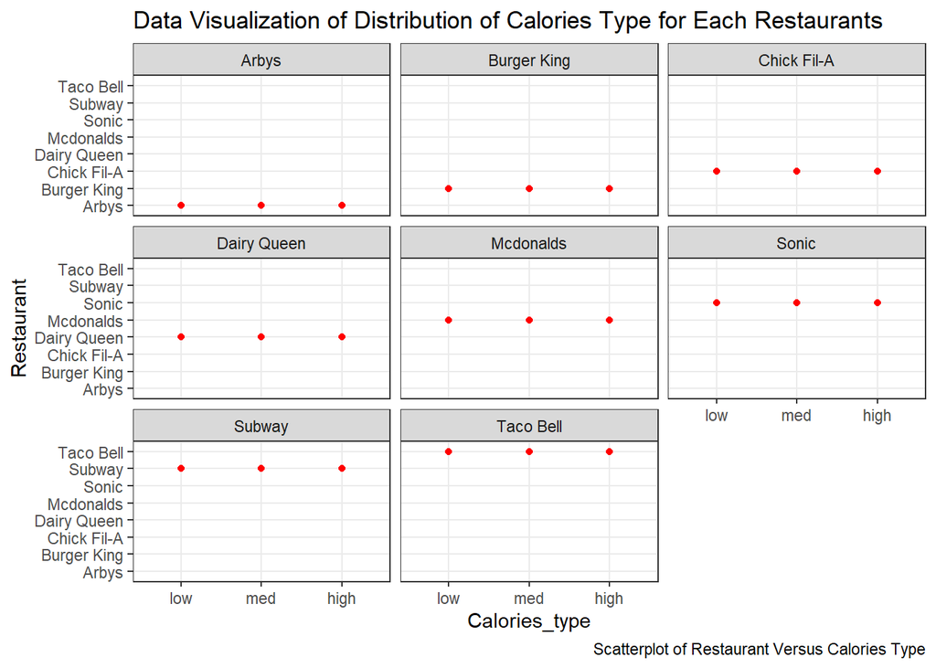

```r
calories_type %>%
  group_by(restaurant) %>%
  ungroup() %>%
  ggplot(aes(x = restaurant, y = calories_type, fct_reorder(restaurant, calories_type))) +
  geom_point(color="red") +
  facet_wrap(~restaurant) +
  coord_flip() +
  theme_bw() +
  labs(x="Restaurant", y="Calories_type", title="Data Visualization of Distribution of Calories Type for Each Restaurants ", caption="Scatterplot of Restaurant Versus Calories Type")
```